# Analysis-of-Gaming-based-on-2025-data

Author

Oscar Romero Mendoza

## Librerias

```r
library(rpart)
library(tidyverse)
library(ggplot2)
library(funModeling)
library(janitor)
library(here)
```

# KDD

## Diccionario de variables

El conjunto de datos contiene 10,003 registros de videojuegos y 12 variables que traía el archivo CSV. Las URL de la variable `image` apuntan a `media.rawg.io`, por lo que los datos parecen provenir de la API de RAWG.

| Variable | Tipo en R | Ejemplo | Descripción | Rol previsto |
| --- | --- | --- | --- | --- |
| `id` | numérica | 58781 | Identificador único del juego en la fuente. | Identificador (se usa solo para detectar duplicados) |
| `name` | texto | The Elder Scrolls VI | Título del videojuego. | Identificador |
| `released` | texto (`dd-mm-yyyy`) | 20-02-2020 | Fecha de lanzamiento. Se convierte a fecha con `dmy()` y se usa únicamente el año, porque en juegos antiguos el día y el mes son un “1 de enero” de relleno. | Predictora |
| `updated` | fecha-hora | 2025-06-12 15:08:44 | Fecha y hora de la última modificación del registro en la fuente. No describe al juego, sino al registro. | Metadato (se usa para elegir el registro más reciente entre duplicados) |
| `rating` | numérica | 4.83 | Calificación promedio de los usuarios. Toma valores entre 3.29 y 5.00. El conjunto de datos no incluye el número de votos que respalda cada calificación. | Variable objetivo |
| `suggestions_count` | numérica | 300 | Número de sugerencias asociadas al juego. Por confirmar en la documentación de RAWG: probablemente cuenta juegos similares sugeridos y no reseñas. | Predictora |
| `platforms` | texto (lista separada por comas) | PC, Xbox Series S/X | Plataformas en las que el juego está disponible. | Predictora |
| `developers` | texto (lista separada por comas) | Bethesda Game Studios | Estudios que desarrollaron el juego. | Predictora |
| `genres` | texto (lista separada por comas) | Action, RPG | Géneros del juego. Un mismo juego puede tener varios. | Predictora |
| `publishers` | texto (lista separada por comas) | Bethesda Softworks | Empresas que publicaron el juego. | Predictora |
| `image` | texto (URL) | https://media.rawg.io/… | Enlace a una imagen del juego (captura o portada) alojada en la fuente. | Descartable |
| `description` | texto libre | Currently in pre-production at… | Descripción textual del juego. | Descartable |

**Notas (priorí) sobre la estructura de los datos**

- `platforms`, `developers`, `genres` y `publishers` guardan varios valores en una sola celda, separados por coma y espacio. Para contar frecuencias hay que separarlos antes (ver la sección de variables categóricas).
- `rating` es la variable que se intentará predecir, y las demás variables se evalúan como posibles predictoras. Esta asignación es provisional y se confirma al cierre del análisis exploratorio (EDA).
- `image` y `description` no se analizan: la primera es un enlace y la segunda es texto libre cuyo análisis requeriría minería de texto, fuera del alcance del proyecto.

## ETL

### Extracción

```r
df <- read_csv(
  here("Data", "Raw", "10K Most Popular Gaming 2025.csv"),
  show_col_types = FALSE
) |>
  select(-1) |>        # columna de índice sobrante
  clean_names()
```

```r
#|label: summary-df
summary(df)
```

```
       id              name             released
 Min.   :      3   Length:10003       Length:10003
 1st Qu.:  18702   Class :character   Class :character
 Median :  40751   Mode  :character   Mode  :character
 Mean   : 170247
 3rd Qu.: 279589
 Max.   :1003457
    updated                        rating      suggestions_count
 Min.   :2019-01-09 12:41:06   Min.   :3.290   Min.   :   0
 1st Qu.:2024-04-16 14:08:57   1st Qu.:3.750   1st Qu.: 211
 Median :2025-03-22 11:53:03   Median :3.890   Median : 339
 Mean   :2024-09-13 20:32:54   Mean   :3.903   Mean   : 348
 3rd Qu.:2025-06-24 16:46:02   3rd Qu.:4.140   3rd Qu.: 477
 Max.   :2025-08-16 22:03:24   Max.   :5.000   Max.   :1729
  platforms          developers           genres           publishers
 Length:10003       Length:10003       Length:10003       Length:10003
 Class :character   Class :character   Class :character   Class :character
 Mode  :character   Mode  :character   Mode  :character   Mode  :character



    image           description
 Length:10003       Length:10003
 Class :character   Class :character
 Mode  :character   Mode  :character
```

```r
str(df)
```

```
tibble [10,003 × 12] (S3: tbl_df/tbl/data.frame)
 $ id               : num [1:10003] 428090 58781 964507 830060 484878 ...
 $ name             : chr [1:10003] "Hazumi and the Pregnation" "The Elder Scrolls VI" "Geometry Dash RazorLeaf" "Sonic Triple Trouble 16-Bit (NoahNCopeland)" ...
 $ released         : chr [1:10003] "20-02-2020" NA "19-07-2023" "02-08-2022" ...
 $ updated          : POSIXct[1:10003], format: "2025-06-12 15:08:44" "2024-04-12 10:28:14" ...
 $ rating           : num [1:10003] 5 4.86 4.83 4.83 4.83 4.83 4.83 4.82 4.79 4.76 ...
 $ suggestions_count: num [1:10003] 300 45 27 211 385 177 257 634 88 588 ...
 $ platforms        : chr [1:10003] "PC" "PC, Xbox Series S/X" "Android, PC" "PC" ...
 $ developers       : chr [1:10003] "Mihiraghi" "Bethesda Game Studios" NA NA ...
 $ genres           : chr [1:10003] "RPG, Indie" "Action, RPG" "Arcade, Casual, Indie" "Action, Adventure, Indie, Platformer" ...
 $ publishers       : chr [1:10003] "Mihiraghi" "Bethesda Softworks" NA NA ...
 $ image            : chr [1:10003] "https://media.rawg.io/media/screenshots/bcd/bcdcee4066b1eb3fb8e949189088314f.jpg" "https://media.rawg.io/media/games/b40/b40eba32d8715d5fdf9634939fe0eca3.jpg" "https://media.rawg.io/media/screenshots/8ad/8ad83b99a7ea2116a72688ba26644b3f.jpg" "https://media.rawg.i…
 $ description      : chr [1:10003] "Mature Content Description\r\nAll characters depicted are age 18 years or older.\r\nThis game contains graphic "| __truncated__ "Currently in pre-production at Bethesda Game Studios, the acclaimed developers of Skyrim and Fallout 4. The hig"| __truncated__ NA "Wh…
```

```r
head(df,5)
```

```
# A tibble: 5 × 12
      id name    released updated             rating suggestions_count platforms
   <dbl> <chr>   <chr>    <dttm>               <dbl>             <dbl> <chr>
1 428090 Hazumi… 20-02-2… 2025-06-12 15:08:44   5                  300 PC
2  58781 The El… <NA>     2024-04-12 10:28:14   4.86                45 PC, Xbox…
3 964507 Geomet… 19-07-2… 2025-07-16 18:31:29   4.83                27 Android,…
4 830060 Sonic … 02-08-2… 2025-02-13 23:27:58   4.83               211 PC
5 484878 ATRI -… 18-06-2… 2025-07-09 10:55:10   4.83               385 PC
# ℹ 5 more variables: developers <chr>, genres <chr>, publishers <chr>,
#   image <chr>, description <chr>
```

## Análisis exploratorio (EDA)

### Calidad de los datos

```r
df_status(df)
```

```
            variable q_zeros p_zeros q_na p_na q_inf p_inf           type
1                 id       0    0.00    0 0.00     0     0        numeric
2               name       0    0.00    0 0.00     0     0      character
3           released       0    0.00  177 1.77     0     0      character
4            updated       0    0.00    0 0.00     0     0 POSIXct/POSIXt
5             rating       0    0.00    0 0.00     0     0        numeric
6  suggestions_count      55    0.55    0 0.00     0     0        numeric
7          platforms       0    0.00   13 0.13     0     0      character
8         developers       0    0.00  302 3.02     0     0      character
9             genres       0    0.00  404 4.04     0     0      character
10        publishers       0    0.00  555 5.55     0     0      character
11             image       0    0.00   42 0.42     0     0      character
12       description       0    0.00  964 9.64     0     0      character
   unique
1    8978
2    8978
3    4936
4    8810
5     130
6     820
7    2765
8    5154
9     676
10   3596
11   8940
12   8091
```

### Eliminación de duplicados y estado

```r
# df1: Copias exactas eliminadas, de cada id se conserva el registro más reciente.
df1 <- df |>
  distinct() |>
  slice_max(updated, by = id, with_ties = FALSE)

str(df1)
```

```
tibble [8,978 × 12] (S3: tbl_df/tbl/data.frame)
 $ id               : num [1:8978] 428090 58781 964507 830060 484878 ...
 $ name             : chr [1:8978] "Hazumi and the Pregnation" "The Elder Scrolls VI" "Geometry Dash RazorLeaf" "Sonic Triple Trouble 16-Bit (NoahNCopeland)" ...
 $ released         : chr [1:8978] "20-02-2020" NA "19-07-2023" "02-08-2022" ...
 $ updated          : POSIXct[1:8978], format: "2025-06-12 15:08:44" "2024-04-12 10:28:14" ...
 $ rating           : num [1:8978] 5 4.86 4.83 4.83 4.83 4.83 4.83 4.82 4.79 4.76 ...
 $ suggestions_count: num [1:8978] 300 45 27 211 385 177 257 634 88 588 ...
 $ platforms        : chr [1:8978] "PC" "PC, Xbox Series S/X" "Android, PC" "PC" ...
 $ developers       : chr [1:8978] "Mihiraghi" "Bethesda Game Studios" NA NA ...
 $ genres           : chr [1:8978] "RPG, Indie" "Action, RPG" "Arcade, Casual, Indie" "Action, Adventure, Indie, Platformer" ...
 $ publishers       : chr [1:8978] "Mihiraghi" "Bethesda Softworks" NA NA ...
 $ image            : chr [1:8978] "https://media.rawg.io/media/screenshots/bcd/bcdcee4066b1eb3fb8e949189088314f.jpg" "https://media.rawg.io/media/games/b40/b40eba32d8715d5fdf9634939fe0eca3.jpg" "https://media.rawg.io/media/screenshots/8ad/8ad83b99a7ea2116a72688ba26644b3f.jpg" "https://media.rawg.io…
 $ description      : chr [1:8978] "Mature Content Description\r\nAll characters depicted are age 18 years or older.\r\nThis game contains graphic "| __truncated__ "Currently in pre-production at Bethesda Game Studios, the acclaimed developers of Skyrim and Fallout 4. The hig"| __truncated__ NA "Wha…
```

```r
df_status(df1)
```

```
            variable q_zeros p_zeros q_na p_na q_inf p_inf           type
1                 id       0    0.00    0 0.00     0     0        numeric
2               name       0    0.00    0 0.00     0     0      character
3           released       0    0.00  155 1.73     0     0      character
4            updated       0    0.00    0 0.00     0     0 POSIXct/POSIXt
5             rating       0    0.00    0 0.00     0     0        numeric
6  suggestions_count      50    0.56    0 0.00     0     0        numeric
7          platforms       0    0.00   11 0.12     0     0      character
8         developers       0    0.00  277 3.09     0     0      character
9             genres       0    0.00  366 4.08     0     0      character
10        publishers       0    0.00  504 5.61     0     0      character
11             image       0    0.00   38 0.42     0     0      character
12       description       0    0.00  865 9.63     0     0      character
   unique
1    8978
2    8978
3    4936
4    8790
5     130
6     820
7    2765
8    5154
9     676
10   3596
11   8940
12   8091
```

- **Tamaño:** 10,003 filas.
- **Duplicados:** unique de id y de name son 8,978 filas, o sea 1,025 menos filas. (Ver str)
- **NA (q_na):** description 964, publishers 555, genres 404, developers 302, released 177, image 42, platforms 13. El resto en cero, incluido rating.
- **Ceros (q_zeros):** suggestions_count debería marcar 55 (0.55%) y rating, 0.
- **Tipos (type):** released aparece como texto y updated como fecha-hora. Esto justifica convertir released con dmy().
- **Limitación:** df_status() solo cuenta NA reales. La revisión de cadenas vacías (ninguna) se hizo aparte y conviene mencionarla en una línea.

### Integridad

```r
data_integrity(df1)
```

```
$vars_num_with_NA
[1] variable q_na     p_na
<0 rows> (or 0-length row.names)

$vars_cat_with_NA
               variable q_na        p_na
description description  865 0.096346625
publishers   publishers  504 0.056137224
genres           genres  366 0.040766318
developers   developers  277 0.030853197
released       released  155 0.017264424
image             image   38 0.004232569
platforms     platforms   11 0.001225217

$vars_cat_high_card
               variable unique
name               name   8978
image             image   8940
description description   8091
developers   developers   5154
released       released   4936
publishers   publishers   3596
platforms     platforms   2765
genres           genres    676

$MAX_UNIQUE
[1] 35

$vars_one_value
character(0)

$vars_cat
[1] "name"        "released"    "platforms"   "developers"  "genres"
[6] "publishers"  "image"       "description"

$vars_num
[1] "id"                "rating"            "suggestions_count"

$vars_char
[1] "name"        "released"    "platforms"   "developers"  "genres"
[6] "publishers"  "image"       "description"

$vars_factor
character(0)

$vars_other
[1] "updated"
```

No hay variables de un solo valor (vars_one_value vacío), los NA coinciden con df_status, y las 8 variables de texto están marcadas como de cardinalidad alta (umbral de 35 únicos). En genres hay 676 combinaciones, pero solo 19 géneros reales.

### Variables numericas

```r
df_num <- df1 |>
  mutate(anio = year(dmy(released))) |>
  select(rating, suggestions_count, anio)
```

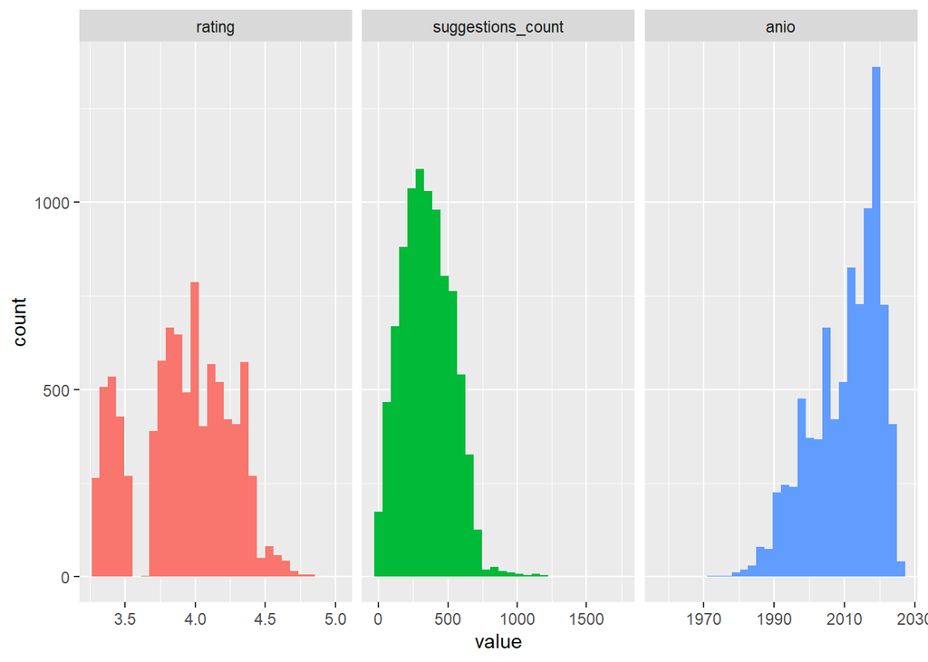

```r
plot_num(df_num, bins = 30)
```

```r
profiling_num(df_num)
```

```
           variable        mean    std_dev variation_coef    p_01    p_05
1            rating    3.908643   0.340356    0.087077775    3.29    3.33
2 suggestions_count  348.234016 181.626485    0.521564456   11.77   66.00
3              anio 2010.461408   9.685491    0.004817546 1985.00 1992.00
     p_25    p_50    p_75   p_95    p_99   skewness kurtosis    iqr
1    3.72    3.93    4.17    4.4    4.58 -0.1818800 2.187811   0.45
2  211.25  338.00  478.00  642.0  777.92  0.4523052 3.661511 266.75
3 2004.00 2013.00 2018.00 2023.0 2024.00 -0.7542694 2.896566  14.00
                   range_98     range_80
1              [3.29, 4.58] [3.39, 4.34]
2 [11.77, 777.919999999998]   [115, 584]
3              [1985, 2024] [1996, 2021]
```

```r
map(df_num, \(x) tukey_outlier(x[!is.na(x)]))
```

```
$rating
bottom_threshold    top_threshold
            2.37             5.52

$suggestions_count
bottom_threshold    top_threshold
         -589.00          1278.25

$anio
bottom_threshold    top_threshold
            1962             2060
```

```r
df_rel <- df1 |>
  mutate(anio = year(dmy(released)), updated_num = as.numeric(updated)) |>
  select(rating, suggestions_count, anio, updated_num)

correlation_table(df_rel, target = "rating")
```

```
           Variable rating
1            rating   1.00
2       updated_num   0.10
3 suggestions_count  -0.05
4              anio  -0.11
```

- **Las tres relaciones son muy débiles.** El valor más alto, 0.11, explica alrededor del 1% de la variación de rating (r² ≈ 0.012).
- **El signo de anio es negativo:** los juegos más recientes tienden a tener ratings algo menores.

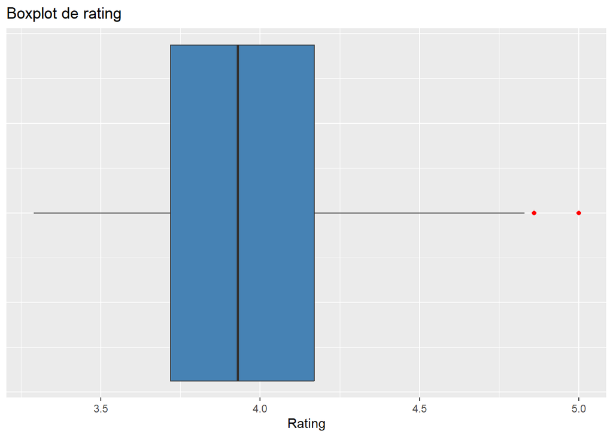

```r
ggplot(df1, aes(x = rating)) +
  geom_boxplot(fill = "steelblue", outlier.color = "red") +
  labs(title = "Boxplot de rating", x = "Rating") +
  theme(axis.text.y = element_blank(), axis.ticks.y = element_blank())
```

*Gráf. Boxplot:* Es univariado para la variable raiting y muestra 2 atípicos superiores.

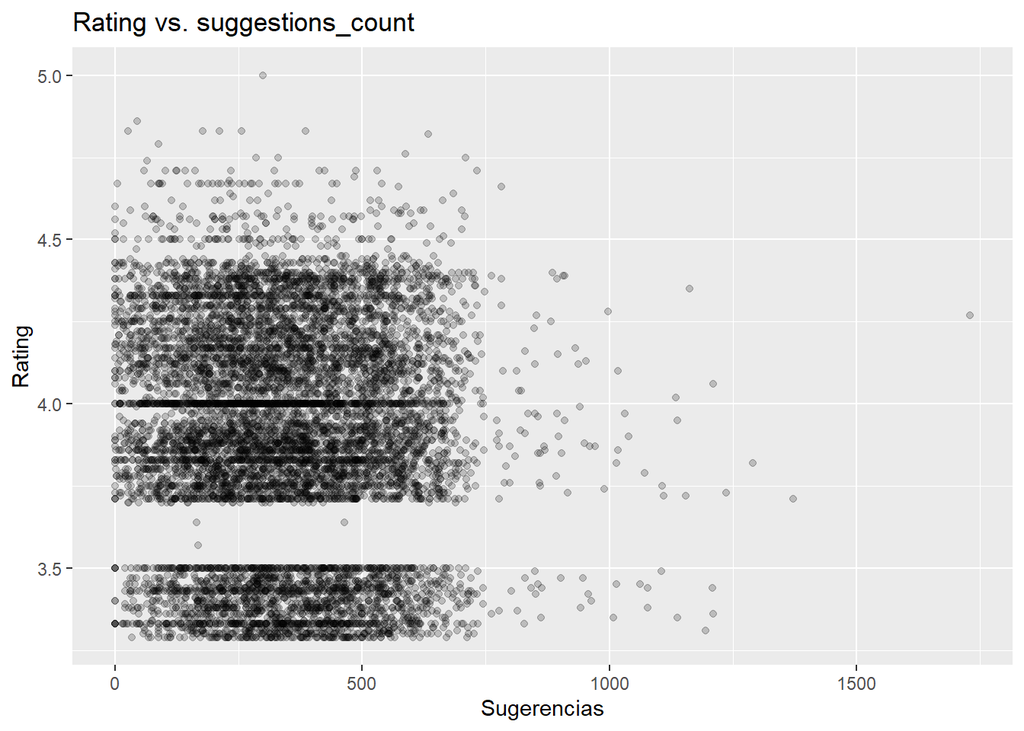

```r
ggplot(df_rel, aes(suggestions_count, rating)) +
  geom_point(alpha = 0.2) +
  labs(title = "Rating vs. suggestions_count", x = "Sugerencias", y = "Rating")
```

- Se esperaba encontrar una tendencia positiva, a mayor cantdidad des sugerencias mayor el rating.
- Una sección (rango) en los datos es casi inexistente, desconosco el motivo. *Hipotesis:* dado que la grafica de disperción muestra claramente lineas horizontales y que los datos estaban organizados de forma decendiente desde un inicio, cabe suponer qué el dataset eso uno ya procesado. **¿Quiza un intento de incrementar el dataset?**

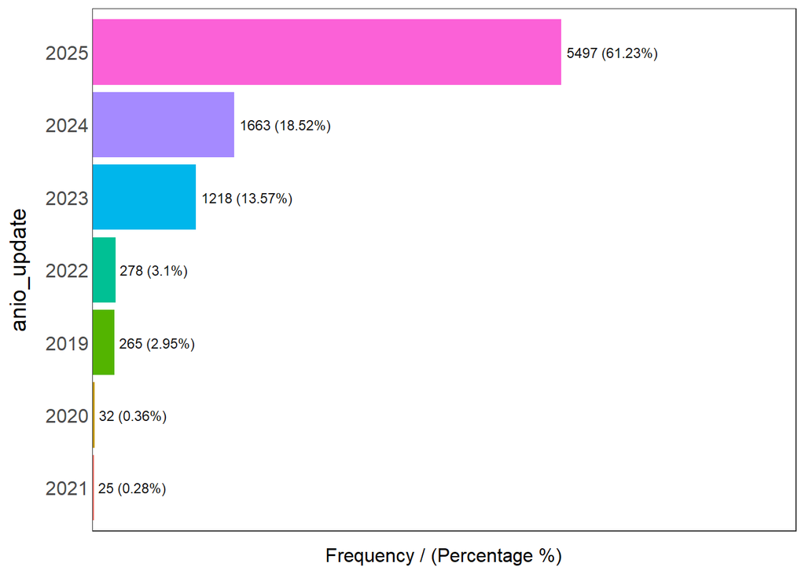

```
  anio_update frequency percentage cumulative_perc
1        2025      5497      61.23           61.23
2        2024      1663      18.52           79.75
3        2023      1218      13.57           93.32
4        2022       278       3.10           96.42
5        2019       265       2.95           99.37
6        2020        32       0.36           99.73
7        2021        25       0.28          100.00
```

```r
df1 |>
  mutate(anio_update = factor(year(updated))) |>
  freq(input = "anio_update")
```

*Gráf. Frecuencia ‘updates’:* El 61.2% de los registros es de 2025, el 18.5% de 2024 y el 13.6% de 2023. Hay 265 de 2019 contra 32 de 2020 y 25 de 2021, un bloque que no he podido explicar.

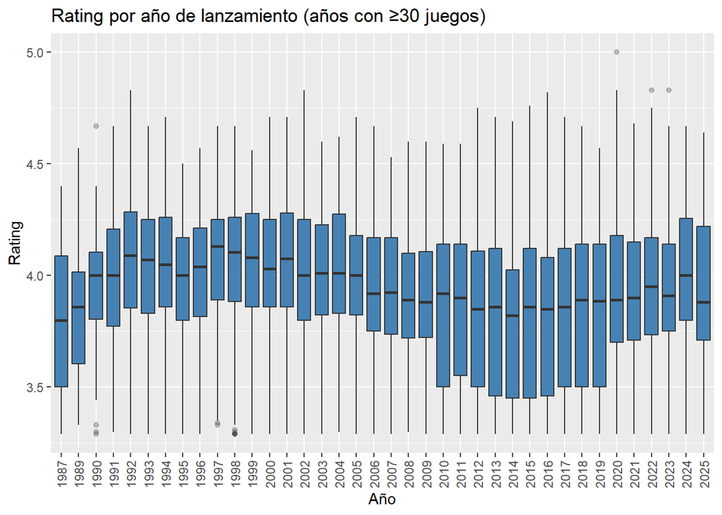

```r
# Años con al menos 30 juegos (excluye los NA para que no aparezca una caja "NA")
anios_ok <- df_rel |>
  filter(!is.na(anio)) |>
  count(anio) |>
  filter(n >= 30) |>
  pull(anio)

df_rel |>
  filter(anio %in% anios_ok) |>
  ggplot(aes(factor(anio), rating)) +
  geom_boxplot(fill = "steelblue", outlier.alpha = 0.3) +
  labs(title = "Rating por año de lanzamiento (años con ≥30 juegos)",
       x = "Año", y = "Rating") +
  theme(axis.text.x = element_text(angle = 90, vjust = 0.5))
```

**Concluciones:** *rating (objetivo):* Media 3.91, mediana 3.93, desviación estándar 0.34, rango de 3.29 a 5.00 y mitad central entre 3.72 y 4.17. Asimetría de -0.18 con la fórmula manual. profiling_num() puede dar un valor ligeramente distinto. El histograma no es una campana: hay un bloque entre 3.3 y 3.5, un hueco casi vacío entre 3.5 y 3.68, un cuerpo principal hasta ~4.4 y una cola corta hacia 5. La causa del hueco sigue sin explicarse. Por IQR, los límites rondan 3.05 y 4.84, y solo hay 2 atípicos altos (5.00 y 4.86). Línea base para la regresión: predecir siempre la media da un RMSE de ~0.34.

*suggestions_count:* El umbral de tukey_outlier() es 1,278, donde 3 juegos lo superan. La media es de 348, la mediana de 338 y la desviación estándar 182, de 0 a 1,729. Casi simétrica, con cola derecha moderada: no requiere transformación. Su significado exacto (probablemente juegos similares sugeridos en la fuente, no reseñas) está por confirmar en la documentación de RAWG. Si lo mencionas en el informe, hazlo como hipótesis. Los ceros (55 en df) quedan pendientes para el tratamiento.

### Variables categoricas

```r
separar_valores <- function(datos, col) {
  datos |>
    select(name, {{ col }}) |>
    filter(!is.na({{ col }})) |>
    separate_longer_delim({{ col }}, delim = ", ")
}

gen_largo <- separar_valores(df1, genres)
pla_largo <- separar_valores(df1, platforms)
dev_largo <- separar_valores(df1, developers)
pub_largo <- separar_valores(df1, publishers)
```

#### Género

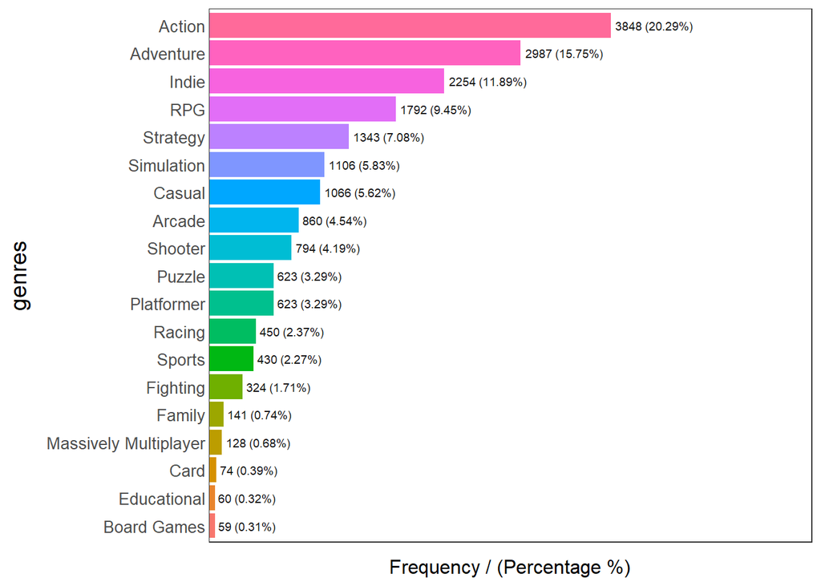

```r
tab_gen <- freq(gen_largo, input = "genres")
```

```r
# El % de freq() es sobre menciones, no sobre juegos (un juego puede tener varios géneros)
tab_gen |>
  mutate(pct_juegos = round(100 * frequency / n_distinct(gen_largo$name), 1))
```

```
                  genres frequency percentage cumulative_perc pct_juegos
1                 Action      3848      20.29           20.29       44.7
2              Adventure      2987      15.75           36.04       34.7
3                  Indie      2254      11.89           47.93       26.2
4                    RPG      1792       9.45           57.38       20.8
5               Strategy      1343       7.08           64.46       15.6
6             Simulation      1106       5.83           70.29       12.8
7                 Casual      1066       5.62           75.91       12.4
8                 Arcade       860       4.54           80.45       10.0
9                Shooter       794       4.19           84.64        9.2
10            Platformer       623       3.29           87.93        7.2
11                Puzzle       623       3.29           91.22        7.2
12                Racing       450       2.37           93.59        5.2
13                Sports       430       2.27           95.86        5.0
14              Fighting       324       1.71           97.57        3.8
15                Family       141       0.74           98.31        1.6
16 Massively Multiplayer       128       0.68           98.99        1.5
17                  Card        74       0.39           99.38        0.9
18           Educational        60       0.32           99.70        0.7
19           Board Games        59       0.31          100.00        0.7
```

Hay 19 generos distintos y todos aparecen en al menos 59 juegos. Action está en el 44.7% de los juegos, Adventure en el 34.7%, Indie en el 26.2% y RPG en el 20.8%. Esos porcentajes son sobre juegos; el de freq() (20.29% para Action) es sobre menciones. Hay 8,612 juegos con género (366 NA). Lo más común son 2 géneros por juego (3,032), luego 1 (2,679) y 3 (1,801).

#### ‘platforms’, ‘developers’ y ‘publishers’

```r
tab_pla <- freq(pla_largo, input = "platforms",  plot = FALSE)
tab_dev <- freq(dev_largo, input = "developers", plot = FALSE)
tab_pub <- freq(pub_largo, input = "publishers", plot = FALSE)

head(tab_pla, 15)
```

```
         platforms frequency percentage cumulative_perc
1               PC      6504      25.70           25.70
2            macOS      1846       7.30           33.00
3    PlayStation 4      1838       7.26           40.26
4         Xbox One      1594       6.30           46.56
5  Nintendo Switch      1480       5.85           52.41
6              iOS      1313       5.19           57.60
7            Linux      1127       4.45           62.05
8          Android      1027       4.06           66.11
9    PlayStation 3       938       3.71           69.82
10        Xbox 360       840       3.32           73.14
11   PlayStation 2       577       2.28           75.42
12   PlayStation 5       470       1.86           77.28
13     PlayStation       449       1.77           79.05
14             Wii       439       1.73           80.78
15 Xbox Series S/X       414       1.64           82.42
```

```r
head(tab_dev, 15)
```

```
                           developers frequency percentage cumulative_perc
1                            Nintendo       201       1.55            1.55
2                              Capcom       196       1.51            3.06
3      Sony Interactive Entertainment       168       1.29            4.35
4                                SEGA       147       1.13            5.48
5        Konami Digital Entertainment       129       0.99            6.47
6                         Square Enix       129       0.99            7.46
7                             Ubisoft       107       0.82            8.28
8                     Electronic Arts        93       0.72            9.00
9              Electronic Arts Canada        70       0.54            9.54
10 BANDAI NAMCO Entertainment America        54       0.42            9.96
11                   Ubisoft Montreal        53       0.41           10.37
12                              Atlus        51       0.39           10.76
13                        id Software        46       0.35           11.11
14                  Feral Interactive        45       0.35           11.46
15                            BioWare        44       0.34           11.80
```

```r
head(tab_pub, 15)
```

```
                       publishers frequency percentage cumulative_perc
1                        Nintendo       499       4.13            4.13
2                 Electronic Arts       457       3.79            7.92
3                            SEGA       346       2.87           10.79
4           Ubisoft Entertainment       258       2.14           12.93
5                          Capcom       252       2.09           15.02
6                     Square Enix       210       1.74           16.76
7                          Konami       192       1.59           18.35
8             Activision Blizzard       178       1.47           19.82
9               Microsoft Studios       168       1.39           21.21
10    Sony Computer Entertainment       165       1.37           22.58
11     Bandai Namco Entertainment       135       1.12           23.70
12                            THQ       103       0.85           24.55
13 Sony Interactive Entertainment       102       0.84           25.39
14             Bethesda Softworks        93       0.77           26.16
15                          Atari        92       0.76           26.92
```

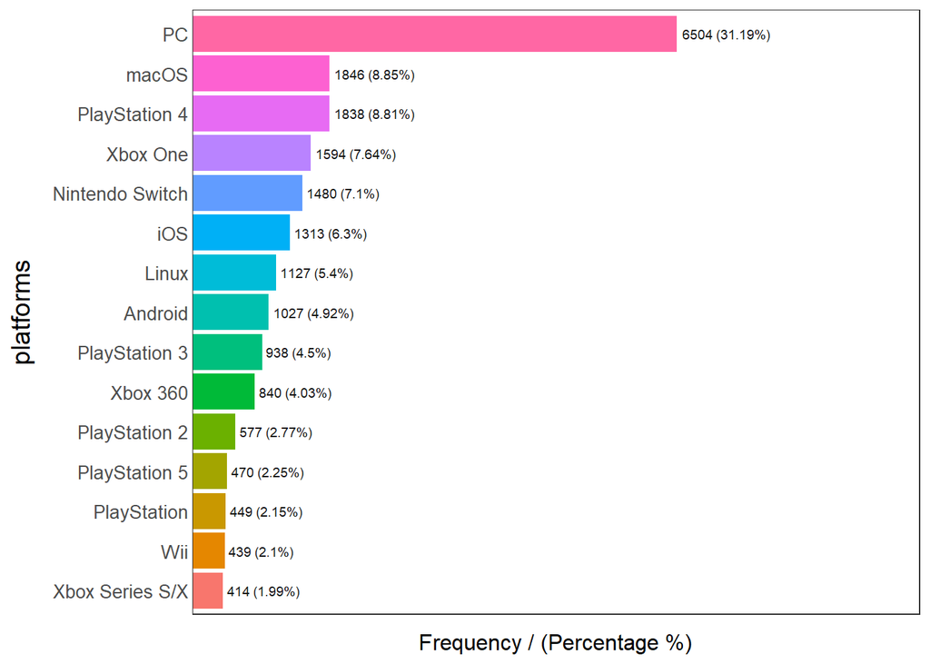

```
         platforms frequency percentage cumulative_perc
1               PC      6504      31.19           31.19
2            macOS      1846       8.85           40.04
3    PlayStation 4      1838       8.81           48.85
4         Xbox One      1594       7.64           56.49
5  Nintendo Switch      1480       7.10           63.59
6              iOS      1313       6.30           69.89
7            Linux      1127       5.40           75.29
8          Android      1027       4.92           80.21
9    PlayStation 3       938       4.50           84.71
10        Xbox 360       840       4.03           88.74
11   PlayStation 2       577       2.77           91.51
12   PlayStation 5       470       2.25           93.76
13     PlayStation       449       2.15           95.91
14             Wii       439       2.10           98.01
15 Xbox Series S/X       414       1.99          100.00
```

```r
# Gráfica de las 15 plataformas principales
pla_largo |>
  filter(platforms %in% head(tab_pla$platforms, 15)) |>
  freq(input = "platforms")
```

```r
tibble(
  variable          = c("genres", "platforms", "developers", "publishers"),
  valores_distintos = c(nrow(tab_gen), nrow(tab_pla), nrow(tab_dev), nrow(tab_pub)),
  con_un_solo_juego = c(sum(tab_gen$frequency == 1), sum(tab_pla$frequency == 1),
                        sum(tab_dev$frequency == 1), sum(tab_pub$frequency == 1)),
  con_30_o_mas      = c(sum(tab_gen$frequency >= 30), sum(tab_pla$frequency >= 30),
                        sum(tab_dev$frequency >= 30), sum(tab_pub$frequency >= 30))
)
```

```
# A tibble: 4 × 4
  variable   valores_distintos con_un_solo_juego con_30_o_mas
  <chr>                  <int>             <int>        <int>
1 genres                    19                 0           19
2 platforms                 51                 0           42
3 developers              5296              3676           34
4 publishers              3343              2285           55
```

```r
df1 |> count(n_generos = str_count(genres, ",") + 1)
```

```
# A tibble: 9 × 2
  n_generos     n
      <dbl> <int>
1         1  2679
2         2  3032
3         3  1801
4         4   774
5         5   253
6         6    60
7         7     9
8         8     4
9        NA   366
```

```r
df1 |> count(n_plataformas = str_count(platforms, ",") + 1)
```

```
# A tibble: 20 × 2
   n_plataformas     n
           <dbl> <int>
 1             1  3254
 2             2  1566
 3             3  1510
 4             4   954
 5             5   688
 6             6   491
 7             7   218
 8             8   142
 9             9    56
10            10    34
11            11    21
12            12    13
13            13    10
14            14     2
15            15     4
16            16     1
17            17     1
18            20     1
19            22     1
20            NA    11
```

```r
# Separar por coma puede partir nombres como "Empresa, Inc."
patron <- regex("^(inc|llc|ltd|co|corp|gmbh)\\.?$", ignore_case = TRUE)
tab_dev |> filter(str_detect(developers, patron))
```

```
  developers frequency percentage cumulative_perc
1         Co         1       0.01           80.61
```

```r
tab_pub |> filter(str_detect(publishers, patron))
```

```
  publishers frequency percentage cumulative_perc
1        Co.         6       0.05           61.53
2        LLC         3       0.02           70.88
3         Co         1       0.01           85.37
```

Plataformas: hay 51 distintas, 42 con al menos 30 juegos. PC está en 6,504 de 8,967 juegos (72.5%). Un juego puede tener hasta 22 plataformas. Desarrolladores: hay 5,296 distintos y 3,676 (69%) tienen un solo juego. Solo 34 llegan a 30 o más. Publishers: 3,343 distintos, 2,285 (68%) con un solo juego, y 55 con 30 o más. Nombres partidos por la coma: afecta solo a 4 filas (Co, Co., LLC, Co). Es poco, pero parecen fragmentos de nombres como “Empresa Co., Ltd.”.

#### Variables no analizadas

Variables que no se analizan. Una línea sobre name, image y description, que se descartan por ser identificador, URL y texto libre. **name:** Esta variable es util como un identificador, por lo que no aporta valor al análisis. **image:** Cada entrada de la variable (en su mayoria) contiene un URL para una imagen del juego. **description:** Un pequeño texto que suele describir el contenido del juego, ya sea historia, jugabilidad, etc.

### Conclusiones (EDA)

**Calidad de los datos.** El archivo original tiene 10,003 registros; al conservar el más reciente de cada `id` quedan 8,978 juegos únicos (1,025 duplicados eliminados). `rating` no tiene NA. Las variables con faltantes son `released` (155), `platforms` (11), `developers` (277), `genres` (366) y `publishers` (504), además de `image` y `description`, que no se usan. En total, 1,004 juegos (11.2 %) tienen al menos un NA en `anio`, `platforms`, `developers`, `genres` o `publishers`, y 135 carecen de `developers` y `publishers` a la vez. En una revisión preliminar, los juegos sin `developers` o sin `publishers` tienen un `rating` promedio más alto (≈ 4.05 y 4.03) que los que sí los tienen (≈ 3.90). Esto sugiere que la ausencia no es completamente aleatoria (MCAR), por lo que eliminar por lista todas las filas incompletas podría sesgar los resultados. Es preferible conservar los casos con indicadores de faltante.

**Variable objetivo.** `rating` va de 3.29 a 5.00, con media 3.91, mediana 3.93 y desviación estándar 0.34. Su distribución no es una campana: hay un bloque entre 3.3 y 3.5, un hueco casi vacío entre 3.5 y 3.68 y una cola corta hacia 5. La causa del hueco no está explicada. Solo hay dos valores atípicos altos (5.00 y 4.86), que son legítimos. Predecir siempre la media da un RMSE ≈ 0.34, que será la línea base del modelo.

**Variables numéricas.** Las relaciones con `rating` son muy débiles: `anio` (−0.11), `updated` (0.10) y `suggestions_count` (−0.05), de modo que ninguna explica más del 1 % de su variación. Los juegos más recientes tienden a tener ratings algo menores. `suggestions_count` es casi simétrica (media 348, mediana 338) y no requiere transformación; sus 50 ceros (0.56 %) son pocos. `anio` se concentra entre 1990 y 2025, con un máximo hacia 2016–2018; 2025 está incompleto, hay 4 lanzamientos posteriores a la extracción (16-ago-2025) y las fechas del 1 de enero son relleno de la fuente, por lo que solo el año es fiable.

**Variables categóricas.** `genres`, `platforms`, `developers` y `publishers` guardan varios valores por celda. Hay 19 géneros reales (Action en 44.7 % de los juegos, Adventure 34.7 %, Indie 26.2 %, RPG 20.8 %) y 51 plataformas (PC en 72.5 %). En cambio, `developers` (5,296 distintos) y `publishers` (3,343) tienen cardinalidad muy alta: alrededor del 69 % aparece en un solo juego y solo 34 y 55 llegan a 30 o más.

**Metadatos.** El 61.2 % de los registros se actualizó en 2025. Hay un bloque de 265 registros de 2019 frente a solo 32 de 2020 y 25 de 2021 que no se explica; una hipótesis es que el conjunto ya venía procesado o combinado de varias extracciones, pero no está confirmada. `updated` describe al registro y no al juego.

**Decisiones para el tratamiento.** - Se confirma `rating` como variable objetivo (regresión). - `id`, `name`, `image` y `description` se descartan del modelo; `updated` se excluye como predictora. - `suggestions_count` se conserva con reserva: su significado está por confirmar y podría ser posterior al éxito del juego. - Las columnas multivalor se separan, los géneros y plataformas se codifican y `developers` y `publishers` se agrupan por frecuencia. - Los faltantes se tratan con indicadores y categoría “Unknown”, y `anio` se imputa solo con entrenamiento.

## Transformación/Tratamiento de los datos

### Diagnóstico de valores faltantes

```r
vars_na <- c("anio", "platforms", "developers", "genres", "publishers")

df_na <- df1 |>
  mutate(anio = year(dmy(released)), updated_num = as.numeric(updated)) |>
  select(all_of(vars_na), rating, suggestions_count, updated_num)
```

```r
resumen_na <- df_na |>
  summarise(across(all_of(vars_na), \(x) sum(is.na(x)))) |>
  pivot_longer(everything(), names_to = "variable", values_to = "q_na") |>
  mutate(p_na = round(100 * q_na / nrow(df_na), 2)) |>
  arrange(desc(q_na))

resumen_na
```

```
# A tibble: 5 × 3
  variable    q_na  p_na
  <chr>      <int> <dbl>
1 publishers   504  5.61
2 genres       366  4.08
3 developers   277  3.09
4 anio         155  1.73
5 platforms     11  0.12
```

```r
# Filas con al menos un NA en estas cinco variables
df_na |>
  mutate(alguno = if_any(all_of(vars_na), is.na)) |>
  summarise(filas_con_na = sum(alguno),
            p_filas_con_na = round(100 * mean(alguno), 2))
```

```
# A tibble: 1 × 2
  filas_con_na p_filas_con_na
         <int>          <dbl>
1         1004           11.2
```

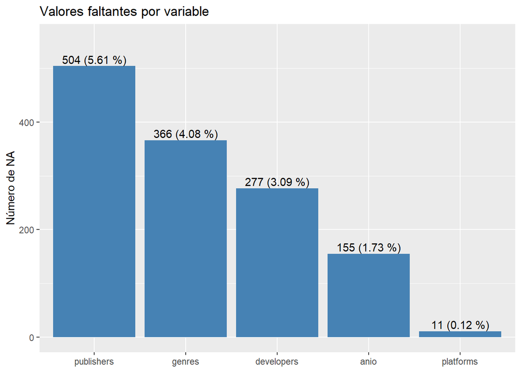

```r
ggplot(resumen_na, aes(reorder(variable, -q_na), q_na)) +
  geom_col(fill = "steelblue") +
  geom_text(aes(label = paste0(q_na, " (", p_na, " %)")), vjust = -0.3) +
  labs(title = "Valores faltantes por variable",
       x = NULL, y = "Número de NA") +
  expand_limits(y = max(resumen_na$q_na) * 1.1)
```

**Gráf. Barras - Distrubución de faltantes:** publishers es la variable con más faltantes *(5.61 %)*, seguida de genres *(4.08 %)*, developers *(3.09 %)*, anio *(1.73 %)* y platforms *(0.12 %)*. Ninguna variable supera el 6 %, *pero al combinarlas 1,004 juegos (11.18 %) tienen al menos un NA*, por lo que eliminarlos todos por lista costaría más de una décima parte de la muestra.

```r
faltantes <- df_na |>
  mutate(across(all_of(vars_na), is.na)) |>
  count(across(all_of(vars_na)), name = "n") |>
  arrange(desc(n)) |>
  mutate(patron = row_number(),
         n_na = rowSums(across(all_of(vars_na))))

faltantes
```

```
# A tibble: 16 × 8
   anio  platforms developers genres publishers     n patron  n_na
   <lgl> <lgl>     <lgl>      <lgl>  <lgl>      <int>  <int> <dbl>
 1 FALSE FALSE     FALSE      FALSE  FALSE       7974      1     0
 2 FALSE FALSE     FALSE      FALSE  TRUE         253      2     1
 3 FALSE FALSE     FALSE      TRUE   FALSE        230      3     1
 4 FALSE FALSE     TRUE       FALSE  TRUE         123      4     2
 5 TRUE  FALSE     FALSE      FALSE  FALSE        120      5     1
 6 FALSE FALSE     TRUE       FALSE  FALSE        101      6     1
 7 FALSE FALSE     FALSE      TRUE   TRUE          88      7     2
 8 FALSE FALSE     TRUE       TRUE   FALSE         41      8     2
 9 TRUE  FALSE     FALSE      FALSE  TRUE          25      9     2
10 FALSE TRUE      FALSE      FALSE  FALSE          5     10     1
11 FALSE TRUE      TRUE       FALSE  TRUE           5     11     3
12 TRUE  FALSE     TRUE       FALSE  TRUE           5     12     3
13 TRUE  FALSE     FALSE      TRUE   FALSE          3     13     2
14 FALSE FALSE     TRUE       TRUE   TRUE           2     14     3
15 TRUE  FALSE     FALSE      TRUE   TRUE           2     15     3
16 FALSE TRUE      FALSE      FALSE  TRUE           1     16     2
```

**Interpretación:** Hay 7,974 juegos completos (88.8 %) y 1,313 celdas faltantes en total. La mayoría de los juegos incompletos falla en una sola variable (709 de 1,004): publishers sola (253), genres sola (230), anio sola (120) y developers sola (101). Solo 14 juegos tienen tres variables faltantes. El patrón conjunto más grande es developers y publishers (123 juegos solo con esas dos; 135 contando los que además carecen de otra variable), seguido de genres con publishers (88). Los faltantes están dispersos en varios patrones pequeños y no se concentran en un solo grupo de filas.

#### Matriz sombra

```r
sombra <- df_na |>
  transmute(across(all_of(vars_na), \(x) as.integer(is.na(x))))

round(cor(sombra), 2)
```

```
            anio platforms developers genres publishers
anio        1.00      0.00       0.00  -0.01       0.09
platforms   0.00      1.00       0.09  -0.01       0.07
developers  0.00      0.09       1.00   0.10       0.33
genres     -0.01     -0.01       0.10   1.00       0.17
publishers  0.09      0.07       0.33   0.17       1.00
```

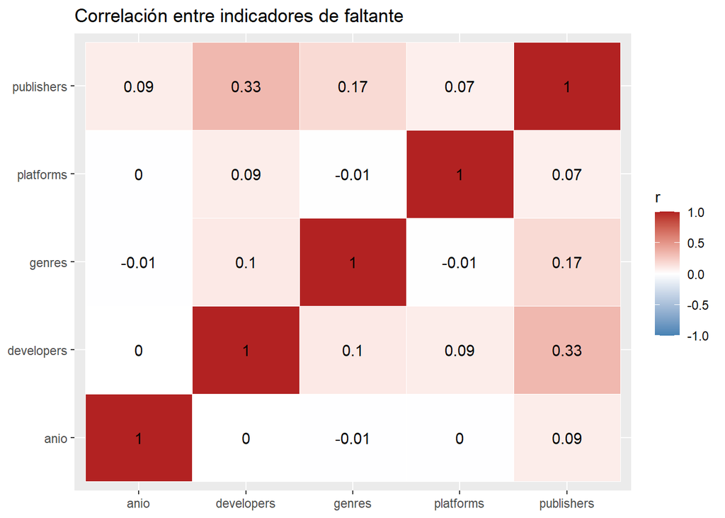

```r
cor(sombra) |>
  as.data.frame() |>
  rownames_to_column("var1") |>
  pivot_longer(-var1, names_to = "var2", values_to = "r") |>
  ggplot(aes(var1, var2, fill = r)) +
  geom_tile(color = "white") +
  geom_text(aes(label = round(r, 2))) +
  scale_fill_gradient2(low = "steelblue", mid = "white", high = "firebrick",
                       limits = c(-1, 1), name = "r") +
  labs(title = "Correlación entre indicadores de faltante", x = NULL, y = NULL)
```

**Interpretación (sombra):** La correlación más alta es entre developers y publishers (r = 0.33): tienden a faltar juntos, aunque de forma moderada. Le siguen genres con publishers (0.17) y genres con developers (0.10). El resto es prácticamente cero (platforms casi no se relaciona con nada).

### Limpieza —

**Decisiones:**

| Regla | Justificación |
| --- | --- |
| Convertir `released` a `anio` con `dmy()` | Solo el año es fiable (hay muchas fechas de relleno “1 de enero”) |
| Eliminar juegos con `anio` pre-lanzamientos | Son pre-lanzamientos; su rating no es comparable |
| Eliminar filas sin `platforms` (11 filas) | 0.12 %: pérdida despreciable |
| Normalizar texto y descartar fragmentos “Co”, “Co.”, “LLC” | Residuos de separar por coma |

```r
fecha_extraccion <- as.Date("2025-08-16")

df2 <- df1 |>
  mutate(fecha = dmy(released),
         anio  = year(fecha),
         across(c(platforms, developers, genres, publishers), str_squish)) |>
  filter(is.na(fecha) | fecha <= fecha_extraccion,  # sin pre-lanzamientos
         !is.na(platforms))                         # sin filas sin plataforma
```

```r
# Filas antes y después
tibble(conjunto = c("df1", "df2"), filas = c(nrow(df1), nrow(df2)))
```

```
# A tibble: 2 × 2
  conjunto filas
  <chr>    <int>
1 df1       8978
2 df2       8963
```

```r
# Pre-lanzamientos eliminados
df1 |>
  filter(dmy(released) > fecha_extraccion) |>
  select(name, released, rating)
```

```
# A tibble: 4 × 3
  name                                   released   rating
  <chr>                                  <chr>       <dbl>
1 Hollow Knight: Silksong                31-12-2025   4.13
2 Vampire: The Masquerade - Bloodlines 2 31-10-2025   3.91
3 Grand Theft Auto VI                    26-05-2026   3.83
4 The Wolf Among Us 2                    31-12-2025   3.8
```

```r
# NA restantes y efecto sobre el objetivo
df2 |>
  summarise(across(c(anio, platforms, developers, genres, publishers),
                   \(x) sum(is.na(x))))
```

```
# A tibble: 1 × 5
   anio platforms developers genres publishers
  <int>     <int>      <int>  <int>      <int>
1   155         0        272    366        498
```

```r
df2 |> summarise(media = mean(rating), sd = sd(rating))
```

```
# A tibble: 1 × 2
  media    sd
  <dbl> <dbl>
1  3.91 0.340
```

**Interpretación:**

- Pasa de 8,978 a 8,963 filas, 4 pre-lanzamientos y 11 juegos sin plataforma.
- Después de la limpieza quedan 155 NA en anio, 272 en developers, 366 en genres y 498 en publishers (platforms queda sin NA); 993 juegos (11.08 %) conservan al menos un NA.
- El rating no cambia (media 3.91, desviación 0.34), así que las eliminaciones no alteraron la variable objetivo.
- No hay nombres que difieran solo por mayúsculas en ninguna de las cuatro columnas, por lo que no es necesario pasar el texto a minúsculas.

### Selección de columnas

| Variable | Decisión | Motivo |
| --- | --- | --- |
| id | Conservar como llave | Permite volver a df1; no es predictora |
| rating | Variable objetivo | No se imputa ni se transforma |
| anio, suggestions_count | Predictoras numéricas | anio reemplaza a released |
| platforms, developers, genres, publishers | Predictoras categóricas | Con varios valores por celda |
| name | Descartar | Identificador; se recupera con id |
| released, fecha | Descartar Sustituidas por anio |  |
| updated | Descartar | Es metadato del registro, no del juego: su correlación con rating es baja (0.10) |
| image, description | Descartar | URL y texto libre; el análisis de texto queda fuera del alcance |

```r
df3 <- df2 |>
  select(id, rating, anio, suggestions_count,
         platforms, developers, genres, publishers)

glimpse(df3)
```

```
Rows: 8,963
Columns: 8
$ id                <dbl> 428090, 58781, 964507, 830060, 484878, 53962, 53594,…
$ rating            <dbl> 5.00, 4.86, 4.83, 4.83, 4.83, 4.83, 4.83, 4.82, 4.79…
$ anio              <dbl> 2020, NA, 2023, 2022, 2020, 1992, 2002, 2016, 2016, …
$ suggestions_count <dbl> 300, 45, 27, 211, 385, 177, 257, 634, 88, 588, 286, …
$ platforms         <chr> "PC", "PC, Xbox Series S/X", "Android, PC", "PC", "P…
$ developers        <chr> "Mihiraghi", "Bethesda Game Studios", NA, NA, "Front…
$ genres            <chr> "RPG, Indie", "Action, RPG", "Arcade, Casual, Indie"…
$ publishers        <chr> "Mihiraghi", "Bethesda Softworks", NA, NA, "ANIPLEX.…
```

### Ingeniería de características

| Bloque | Características | Cómo se construye |
| --- | --- | --- |
| Género | gen_* (19 columnas 0/1), n_generos | Se separan los géneros de cada celda |
| Plataformas | pf_* (7 familias 0/1), n_plataformas, n_familias, solo_pc, multiplataforma | Cada plataforma se asigna a una familia |
| Tiempo | edad_juego, era | A partir de anio |
| Empresas | autopublicado | Compara developers con publishers |

```r
gen_feat <- df3 |>
  select(id, genres) |>
  filter(!is.na(genres)) |>
  mutate(n_generos = str_count(genres, ",") + 1L) |>
  separate_longer_delim(genres, delim = ", ") |>
  distinct(id, n_generos, genres) |>
  mutate(valor = 1L) |>
  pivot_wider(names_from = genres, values_from = valor,
              values_fill = 0L, names_prefix = "gen_") |>
  clean_names()

gen_feat
```

```
# A tibble: 8,597 × 21
       id n_generos gen_rpg gen_indie gen_action gen_arcade gen_casual
    <dbl>     <int>   <int>     <int>      <int>      <int>      <int>
 1 428090         2       1         1          0          0          0
 2  58781         2       1         0          1          0          0
 3 964507         3       0         1          0          1          1
 4 830060         4       0         1          1          0          0
 5 484878         2       0         0          0          0          1
 6  53594         2       0         0          1          0          0
 7  43252         1       1         0          0          0          0
 8 257255         2       1         0          0          0          0
 9  43050         1       1         0          0          0          0
10 816336         1       0         0          0          0          1
# ℹ 8,587 more rows
# ℹ 14 more variables: gen_adventure <int>, gen_platformer <int>,
#   gen_strategy <int>, gen_shooter <int>, gen_fighting <int>,
#   gen_simulation <int>, gen_massively_multiplayer <int>, gen_puzzle <int>,
#   gen_racing <int>, gen_sports <int>, gen_educational <int>,
#   gen_family <int>, gen_card <int>, gen_board_games <int>
```

```r
pla_larga <- df3 |>
  select(id, platforms) |>
  separate_longer_delim(platforms, delim = ", ") |>
  mutate(familia = case_when(
    str_detect(platforms, "^(PlayStation|PS Vita|PSP)")         ~ "playstation",
    str_detect(platforms, "^Xbox")                               ~ "xbox",
    str_detect(platforms, "Nintendo|Wii|GameCube|Game Boy|NES")  ~ "nintendo",
    platforms %in% c("PC", "macOS", "Linux")                     ~ "pc",
    platforms %in% c("iOS", "Android")                           ~ "movil",
    str_detect(platforms, "SEGA|Genesis|Dreamcast|Game Gear")    ~ "sega",
    TRUE                                                         ~ "otras"))

# Revisión de la asignación (51 filas)
pla_larga |> distinct(platforms, familia) |> arrange(familia, platforms)
```

```
# A tibble: 51 × 2
   platforms        familia
   <chr>            <chr>
 1 Android          movil
 2 iOS              movil
 3 Game Boy         nintendo
 4 Game Boy Advance nintendo
 5 Game Boy Color   nintendo
 6 GameCube         nintendo
 7 NES              nintendo
 8 Nintendo 3DS     nintendo
 9 Nintendo 64      nintendo
10 Nintendo DS      nintendo
# ℹ 41 more rows
```

```r
pla_n <- pla_larga |> count(id, name = "n_plataformas")

pla_fam <- pla_larga |>
  distinct(id, familia) |>
  mutate(valor = 1L) |>
  pivot_wider(names_from = familia, values_from = valor,
              values_fill = 0L, names_prefix = "pf_")

pla_feat <- pla_n |>
  left_join(pla_fam, by = "id") |>
  mutate(n_familias      = as.integer(rowSums(across(starts_with("pf_")))),
         solo_pc         = as.integer(pf_pc == 1 & n_familias == 1),
         multiplataforma = as.integer(n_familias >= 2))

pla_n
```

```
# A tibble: 8,963 × 2
      id n_plataformas
   <dbl>         <int>
 1     3             4
 2    14             7
 3    20             3
 4    22             1
 5    24             1
 6    25             4
 7    26             2
 8    27             4
 9    28             3
10    29             4
# ℹ 8,953 more rows
```

```r
anio_ref <- 2025

crear_tiempo <- function(d) {
  d |>
    mutate(edad_juego = anio_ref - anio,
           era = cut(anio,
                     breaks = c(-Inf, 1999, 2009, 2019, Inf),
                     labels = c("antes_2000", "2000_2009", "2010_2019", "2020_mas")))
}
```

```r
df4 <- df3 |>
  left_join(gen_feat, by = "id") |>
  left_join(pla_feat, by = "id") |>
  mutate(across(c(n_generos, starts_with("gen_")), \(x) replace_na(x, 0L)),
         autopublicado = case_when(
           is.na(developers) | is.na(publishers) ~ NA_integer_,
           developers == publishers              ~ 1L,
           TRUE                                  ~ 0L)) |>
  crear_tiempo()
```

```r
dim(df4)
```

```
[1] 8963   42
```

```r
# Consistencia: n_generos coincide con la suma de columnas gen_*
all(df4$n_generos == rowSums(select(df4, starts_with("gen_"))))
```

```
[1] TRUE
```

```r
# Columnas nuevas con NA (se tratan en los pasos 5 y 7)
df4 |>
  summarise(across(c(autopublicado, edad_juego, era), \(x) sum(is.na(x))))
```

```
# A tibble: 1 × 3
  autopublicado edad_juego   era
          <int>      <int> <int>
1           640        155   155
```

```r
df4 |> count(era)
```

```
# A tibble: 5 × 2
  era            n
  <fct>      <int>
1 antes_2000  1407
2 2000_2009   2071
3 2010_2019   3724
4 2020_mas    1606
5 <NA>         155
```

```r
df4 |> count(autopublicado)
```

```
# A tibble: 3 × 2
  autopublicado     n
          <int> <int>
1             0  6114
2             1  2209
3            NA   640
```

```r
df4 |> count(n_familias)
```

```
# A tibble: 7 × 2
  n_familias     n
       <int> <int>
1          1  4557
2          2  1579
3          3  1421
4          4  1061
5          5   304
6          6    30
7          7    11
```

**Interpretación I:** - df4 tiene 8,963 filas y 42 columnas, las 8 de df3 más 34 nuevas (20 de género, 11 de plataformas, autopublicado, edad_juego y era). - La revisión de la asignación de familias no debe dejar plataformas mal clasificadas, y n_generos coincide con la suma de columnas gen_*. Las nuevas columnas con NA son edad_juego y era (155, los mismos de anio) y autopublicado (640, por faltar developers o publishers). - Más de la mitad de los juegos (4,557) están en una sola familia de plataformas, y 4,406 son multiplataforma.

```r
dif_rating <- function(d, cols) {
  d |>
    select(rating, {{ cols }}) |>
    pivot_longer(-rating, names_to = "caracteristica", values_to = "valor") |>
    group_by(caracteristica) |>
    summarise(n_con      = sum(valor == 1),
              media_con  = mean(rating[valor == 1]),
              media_sin  = mean(rating[valor == 0]),
              dif        = media_con - media_sin,
              .groups = "drop") |>
    mutate(across(c(media_con, media_sin, dif), \(x) round(x, 3))) |>
    arrange(dif)
}

# Géneros (solo juegos con género conocido)
dif_rating(filter(df4, !is.na(genres)), starts_with("gen_"))
```

```
# A tibble: 19 × 5
   caracteristica            n_con media_con media_sin    dif
   <chr>                     <int>     <dbl>     <dbl>  <dbl>
 1 gen_indie                  2253      3.81      3.94 -0.137
 2 gen_sports                  429      3.83      3.91 -0.081
 3 gen_massively_multiplayer   128      3.84      3.91 -0.072
 4 gen_simulation             1106      3.85      3.92 -0.068
 5 gen_card                     74      3.84      3.91 -0.063
 6 gen_casual                 1066      3.86      3.92 -0.06
 7 gen_board_games              59      3.86      3.91 -0.051
 8 gen_family                  141      3.86      3.91 -0.049
 9 gen_action                 3841      3.88      3.93 -0.041
10 gen_adventure              2984      3.88      3.92 -0.036
11 gen_strategy               1343      3.88      3.91 -0.028
12 gen_shooter                 790      3.89      3.91 -0.018
13 gen_arcade                  857      3.90      3.91 -0.005
14 gen_puzzle                  622      3.92      3.91  0.015
15 gen_rpg                    1790      3.92      3.90  0.017
16 gen_fighting                323      3.93      3.91  0.02
17 gen_racing                  450      3.93      3.91  0.021
18 gen_educational              60      3.96      3.91  0.05
19 gen_platformer              622      3.96      3.90  0.056
```

```r
# Plataformas
dif_rating(df4, c(starts_with("pf_"), solo_pc, multiplataforma))
```

```
# A tibble: 9 × 5
  caracteristica  n_con media_con media_sin    dif
  <chr>           <int>     <dbl>     <dbl>  <dbl>
1 pf_pc            6515      3.88      3.99 -0.107
2 pf_xbox          2467      3.85      3.93 -0.08
3 multiplataforma  4406      3.88      3.94 -0.065
4 pf_playstation   3609      3.89      3.92 -0.032
5 solo_pc          2706      3.89      3.92 -0.022
6 pf_movil         1471      3.91      3.91 -0.002
7 pf_nintendo      3027      3.92      3.90  0.02
8 pf_otras          449      3.95      3.91  0.041
9 pf_sega           461      4.00      3.90  0.093
```

```r
# Correlación con rating (n_generos solo con género conocido)
cor(df4$edad_juego, df4$rating, use = "complete.obs")
```

```
[1] 0.112671
```

```r
cor(df4$n_plataformas, df4$rating)
```

```
[1] -0.07047033
```

```r
cor(df4$n_familias, df4$rating)
```

```
[1] -0.08135814
```

```r
df4 |> filter(!is.na(genres)) |> summarise(r = cor(n_generos, rating))
```

```
# A tibble: 1 × 1
       r
   <dbl>
1 -0.160
```

```r
# Rating por era y por autopublicado
df4 |>
  filter(!is.na(era)) |>
  group_by(era) |>
  summarise(n = n(), media = mean(rating), sd = sd(rating))
```

```
# A tibble: 4 × 4
  era            n media    sd
  <fct>      <int> <dbl> <dbl>
1 antes_2000  1407  3.98 0.312
2 2000_2009   2071  3.96 0.321
3 2010_2019   3724  3.85 0.346
4 2020_mas    1606  3.91 0.345
```

```r
df4 |>
  filter(!is.na(autopublicado)) |>
  group_by(autopublicado) |>
  summarise(n = n(), media = mean(rating), sd = sd(rating))
```

```
# A tibble: 2 × 4
  autopublicado     n media    sd
          <int> <int> <dbl> <dbl>
1             0  6114  3.91 0.334
2             1  2209  3.88 0.352
```

### Tratamiento de faltantes

```r
# Tasa de coincidencia developers == publishers en casos completos
completos <- df4 |> filter(!is.na(developers), !is.na(publishers))
tibble(casos_completos = nrow(completos),
       tasa_coincidencia = round(mean(completos$developers == completos$publishers), 3))
```

```
# A tibble: 1 × 2
  casos_completos tasa_coincidencia
            <int>             <dbl>
1            8323             0.265
```

```r
# Cuántas filas recuperaría la regla de copiar (solo para justificar el descarte)
df4 |>
  summarise(solo_falta_publisher = sum(!is.na(developers) &  is.na(publishers)),
            solo_falta_developer = sum( is.na(developers) & !is.na(publishers)),
            faltan_ambos         = sum( is.na(developers) &  is.na(publishers)))
```

```
# A tibble: 1 × 3
  solo_falta_publisher solo_falta_developer faltan_ambos
                 <int>                <int>        <int>
1                  368                  142          130
```

```r
# ¿Los ceros de suggestions_count tienen un patrón?
df4 |>
  mutate(cero = suggestions_count == 0) |>
  group_by(cero) |>
  summarise(n = n(), rating_medio = mean(rating), anio_medio = mean(anio, na.rm = TRUE))
```

```
# A tibble: 2 × 4
  cero      n rating_medio anio_medio
  <lgl> <int>        <dbl>      <dbl>
1 FALSE  8914         3.91      2010.
2 TRUE     49         4.00      2013.
```

```r
t.test(rating ~ (suggestions_count == 0), data = df4)
```

```
    Welch Two Sample t-test

data:  rating by suggestions_count == 0
t = -1.6154, df = 48.397, p-value = 0.1127
alternative hypothesis: true difference in means between group FALSE and group TRUE is not equal to 0
95 percent confidence interval:
 -0.20374482  0.02218905
sample estimates:
mean in group FALSE  mean in group TRUE
           3.908202            3.998980
```

```r
df5 <- df4 |>
  mutate(
    genero_na         = as.integer(is.na(genres)),
    anio_na           = as.integer(is.na(anio)),
    developer_unknown = as.integer(is.na(developers)),
    publisher_unknown = as.integer(is.na(publishers)),
    developers        = replace_na(developers, "Unknown"),
    publishers        = replace_na(publishers, "Unknown"),
    # autopublicado era NA cuando faltaba developers o publishers; esa
    # información ya la llevan los dos indicadores *_unknown, así que se pasa a 0
    autopublicado     = replace_na(autopublicado, 0L)
  )

dim(df5)
```

```
[1] 8963   46
```

```r
df5 |> summarise(across(c(genero_na, anio_na, developer_unknown, publisher_unknown), sum))
```

```
# A tibble: 1 × 4
  genero_na anio_na developer_unknown publisher_unknown
      <int>   <int>             <int>             <int>
1       366     155               272               498
```

### Imputación de `anio`

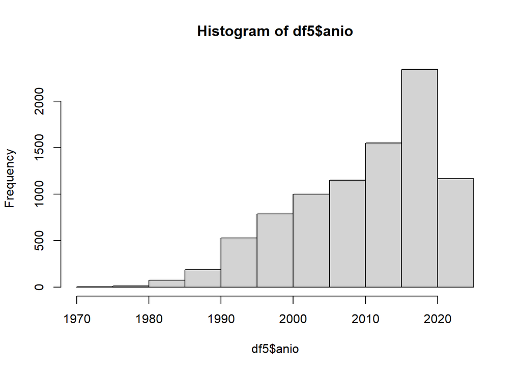

```r
hist(df5$anio)
```

```r
sum(is.na(df5$anio))   # debe dar 0
```

```
[1] 155
```

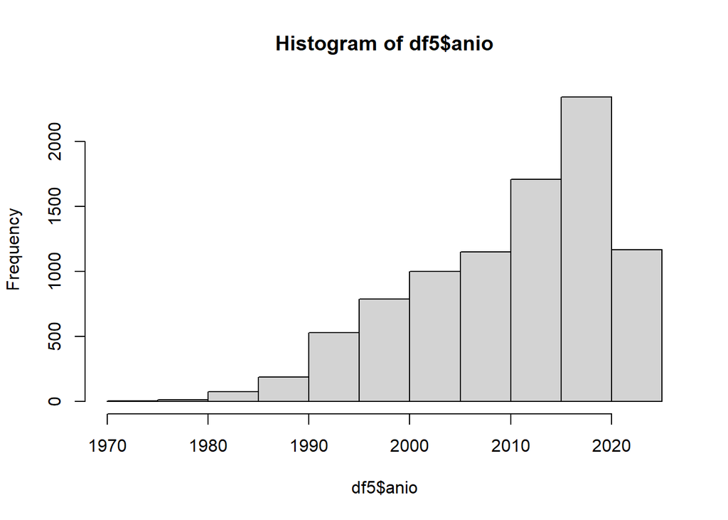

```r
mediana_global <- round(median(df5$anio, na.rm = TRUE))

df5 <- df5 |>
  mutate(anio = if_else(is.na(anio), mediana_global, anio)) |>
  crear_tiempo()   # recalcula edad_juego y era con el anio ya imputado

hist(df5$anio)
```

```r
sum(is.na(df5$anio))   # debe dar 0
```

```
[1] 0
```

**Interpretación:**

- Tras la imputación no quedan NA en anio, edad_juego ni era.
- El histograma muestra una distribución asimétrica hacia la izquierda: pocos juegos antes de 1990, un crecimiento sostenido y un máximo en 2015–2020 (≈ 2,300 juegos), seguido de 2010–2015 (≈ 1,700). La barra de 2020–2025 (≈ 1,200) es menor porque 2025 está incompleto y porque la fuente tiene menos juegos recientes con datos completos.
- Esa forma coincide con lo observado en el EDA (concentración entre 1990 y 2025 y máximo hacia 2016–2018). La imputación no la distorsionó: no aparece ningún pico artificial ni cambia la forma general.
- Como las 155 filas imputadas son solo el 1.73 % del total y reciben un valor central, su efecto en la distribución es pequeño, pero sí le dan un poco más de peso al año de la mediana.

### Alta cardinalidad: developers y publishers

**Decisión.** Hay 5,296 desarrolladores y 3,343 publishers, y cerca del 69 % aparece en un solo juego, así que una columna por empresa no es viable. En vez de eso, cada variable se resume en dos números por juego, calculados con todo el conjunto:

| Variable nueva | Qué mide |
| --- | --- |
| `n_juegos_dev`, `n_juegos_pub` | El mayor número de juegos entre las empresas del juego (tamaño de la empresa) |
| `dev_top`, `pub_top` | 1 si alguna de sus empresas está entre las 10 con más juegos |

Los juegos sin dato quedan en 0 y se distinguen con `developer_unknown` y `publisher_unknown`.

```r
K_emp <- 10

frecuencias <- function(d, col) {
  d |>
    select(id, valor = {{ col }}) |>
    filter(valor != "Unknown") |>
    separate_longer_delim(valor, delim = ", ") |>
    distinct(id, valor) |>
    count(valor, name = "n_juegos")
}

tab_dev <- frecuencias(df5, developers)
tab_pub <- frecuencias(df5, publishers)

devs_frecuentes <- tab_dev |> slice_max(n_juegos, n = K_emp, with_ties = FALSE) |> pull(valor)
pubs_frecuentes <- tab_pub |> slice_max(n_juegos, n = K_emp, with_ties = FALSE) |> pull(valor)

empresas_resumen <- function(d, col, frecuentes, tabla, pref) {
  d |>
    select(id, valor = {{ col }}) |>
    filter(valor != "Unknown") |>
    separate_longer_delim(valor, delim = ", ") |>
    distinct(id, valor) |>
    left_join(tabla, by = "valor") |>
    summarise(!!paste0("n_juegos_", pref) := max(n_juegos),
              !!paste0(pref, "_top")      := as.integer(any(valor %in% frecuentes)),
              .by = id)
}

df6 <- df5 |>
  left_join(empresas_resumen(df5, developers, devs_frecuentes, tab_dev, "dev"), by = "id") |>
  left_join(empresas_resumen(df5, publishers, pubs_frecuentes, tab_pub, "pub"), by = "id") |>
  mutate(across(c(n_juegos_dev, dev_top, n_juegos_pub, pub_top), \(x) replace_na(x, 0L)))

dim(df6)
```

```
[1] 8963   50
```

```r
# Las 10 empresas elegidas
tibble(developers = devs_frecuentes, publishers = pubs_frecuentes)
```

```
# A tibble: 10 × 2
   developers                         publishers
   <chr>                              <chr>
 1 Nintendo                           Nintendo
 2 Capcom                             Electronic Arts
 3 Sony Interactive Entertainment     SEGA
 4 SEGA                               Ubisoft Entertainment
 5 Konami Digital Entertainment       Capcom
 6 Square Enix                        Square Enix
 7 Ubisoft                            Konami
 8 Electronic Arts                    Activision Blizzard
 9 Electronic Arts Canada             Microsoft Studios
10 BANDAI NAMCO Entertainment America Sony Computer Entertainment
```

```r
# % de juegos por categoría
df6 |>
  summarise(pct_dev_unknown = mean(developer_unknown) * 100,
            pct_dev_top     = mean(dev_top) * 100,
            pct_dev_otro    = 100 - pct_dev_unknown - pct_dev_top,
            pct_pub_unknown = mean(publisher_unknown) * 100,
            pct_pub_top     = mean(pub_top) * 100,
            pct_pub_otro    = 100 - pct_pub_unknown - pct_pub_top)
```

```
# A tibble: 1 × 6
  pct_dev_unknown pct_dev_top pct_dev_otro pct_pub_unknown pct_pub_top
            <dbl>       <dbl>        <dbl>           <dbl>       <dbl>
1            3.03        14.0         83.0            5.56        29.2
# ℹ 1 more variable: pct_pub_otro <dbl>
```

### Agrupación de géneros, codificación de `era` y selección final

**Decisión.** Los 19 géneros se agrupan en 4 grupos y `gen_indie` queda aparte, porque es el de mayor diferencia de rating en el paso 4 (−0.137). `n_generos` conserva el conteo completo. `era` pasa a dummies, tomando `antes_2000` como referencia. No se aplica escalado: en regresión lineal no cambia las predicciones, y si se necesita se hará en Modelado con la media y desviación de entrenamiento.

| Grupo | Géneros que incluye |
| --- | --- |
| `gen_g_accion` | Action, Shooter, Fighting, Platformer, Arcade, Racing, Sports |
| `gen_g_aventura_rol` | Adventure, RPG, Massively Multiplayer |
| `gen_g_estrategia` | Strategy, Simulation |
| `gen_g_casual` | Casual, Puzzle, Card, Board Games, Family, Educational |

Los grupos son un criterio propio: se agrupó por parecido de jugabilidad, no con un método estadístico.

```r
grupos_gen <- list(
  gen_g_accion       = c("gen_action", "gen_shooter", "gen_fighting", "gen_platformer",
                         "gen_arcade", "gen_racing", "gen_sports"),
  gen_g_aventura_rol = c("gen_adventure", "gen_rpg", "gen_massively_multiplayer"),
  gen_g_estrategia   = c("gen_strategy", "gen_simulation"),
  gen_g_casual       = c("gen_casual", "gen_puzzle", "gen_card", "gen_board_games",
                         "gen_family", "gen_educational")
)

for (g in names(grupos_gen)) {
  df6[[g]] <- as.integer(rowSums(df6[grupos_gen[[g]]]) > 0)
}

# Ningún género debe quedar sin asignar (debe dar character(0))
setdiff(grep("^gen_[a-z]", names(df6), value = TRUE),
        c(unlist(grupos_gen), "gen_indie", names(grupos_gen)))
```

```
character(0)
```

```r
for (l in levels(df6$era)[-1]) {
  df6[[paste0("era_", l)]] <- as.integer(df6$era == l)
}

df_modelo <- df6 |>
  select(id, rating,
         suggestions_count, edad_juego, n_generos, n_plataformas, n_juegos_dev, n_juegos_pub,
         anio_na, genero_na, developer_unknown, publisher_unknown, autopublicado,
         dev_top, pub_top,
         gen_indie, starts_with("gen_g_"),
         starts_with("pf_"),
         starts_with("era_"))

dim(df_modelo)
```

```
[1] 8963   30
```

**Variables descartadas:**

- `n_familias`, `solo_pc` y `multiplataforma` se derivan de `pf_*` y `n_plataformas`. En particular, `n_familias` es exactamente la suma de las `pf_*` y provocaría colinealidad perfecta.
- `anio` se elimina porque `edad_juego = 2025 − anio`.
- Las 19 columnas `gen_*` se sustituyen por los 4 grupos más `gen_indie`.
- `platforms`, `genres`, `developers`, `publishers`, `era` y `anio` ya están codificadas o resumidas.

**Diccionario del dataset final** (30 columnas: `id` como llave, `rating` como objetivo y 28 predictoras):

| Bloque | Variables | Cómo se construyó |
| --- | --- | --- |
| Numéricas | `suggestions_count` | Original (se conserva con reserva, ver EDA) |
|  | `edad_juego` | 2025 − `anio` (con `anio` imputado) |
|  | `n_generos`, `n_plataformas` | Número de géneros / plataformas del juego |
|  | `n_juegos_dev`, `n_juegos_pub` | Mayor número de juegos entre sus empresas |
| Faltantes | `anio_na`, `genero_na`, `developer_unknown`, `publisher_unknown` | 1 si el dato faltaba |
|  | `autopublicado` | 1 si developers = publishers; 0 si no coinciden o falta alguno |
| Empresas | `dev_top`, `pub_top` | 1 si alguna empresa está entre las 10 con más juegos |
| Género | `gen_indie` | 1 si el juego es Indie |
|  | `gen_g_accion`, `gen_g_aventura_rol`, `gen_g_estrategia`, `gen_g_casual` | 1 si tiene algún género del grupo |
| Plataforma | `pf_playstation`, `pf_xbox`, `pf_nintendo`, `pf_pc`, `pf_movil`, `pf_sega`, `pf_otras` | 1 si está en alguna plataforma de la familia |
| Tiempo | `era_2000_2009`, `era_2010_2019`, `era_2020_mas` | Dummies de `era` (referencia: `antes_2000`) |

### Validación del tratamiento

```r
sum(is.na(df_modelo))   # debe dar 0
```

```
[1] 0
```

```r
# Columnas constantes (no debe haber ninguna)
df_modelo |>
  summarise(across(everything(), n_distinct)) |>
  pivot_longer(everything(), names_to = "variable", values_to = "valores_distintos") |>
  filter(valores_distintos == 1)
```

```
# A tibble: 0 × 2
# ℹ 2 variables: variable <chr>, valores_distintos <int>
```

```r
# Todo numérico
sapply(df_modelo, class) |> table()
```

```
integer numeric
     26       4
```

```r
df_status(df_modelo) |> filter(q_na > 0)
```

[output not shown]

[output cut: 16 more lines]

```
[1] variable q_zeros  p_zeros  q_na     p_na     q_inf    p_inf    type
[9] unique
<0 rows> (or 0-length row.names)
```

Bitácora de decisiones:

[output not shown]